# Price Optimisation based on price elasticity of Demand

```
                            OLS Regression Results
==============================================================================
Dep. Variable:               QUANTITY   R-squared:                       0.215
Model:                            OLS   Adj. R-squared:                  0.214
Method:                 Least Squares   F-statistic:                     228.7
Date:                Mon, 07 Jun 2021   Prob (F-statistic):           7.46e-46
Time:                        21:38:32   Log-Likelihood:                -2347.4
No. Observations:                 837   AIC:                             4699.
Df Residuals:                     835   BIC:                             4708.
Df Model:                           1
Covariance Type:            nonrobust
==============================================================================
                 coef    std err          t      P>|t|      [0.025      0.975]
------------------------------------------------------------------------------
Intercept     51.4615      2.025     25.416      0.000      47.487      55.436
PRICE         -2.5508      0.169    -15.124      0.000      -2.882      -2.220
==============================================================================
Omnibus:                       11.783   Durbin-Watson:                   1.702
Prob(Omnibus):                  0.003   Jarque-Bera (JB):               10.425
Skew:                          -0.214   Prob(JB):                      0.00545
Kurtosis:                       2.659   Cond. No.                         177.
==============================================================================

Notes:
[1] Standard Errors assume that the covariance matrix of the errors is correctly specified.
```

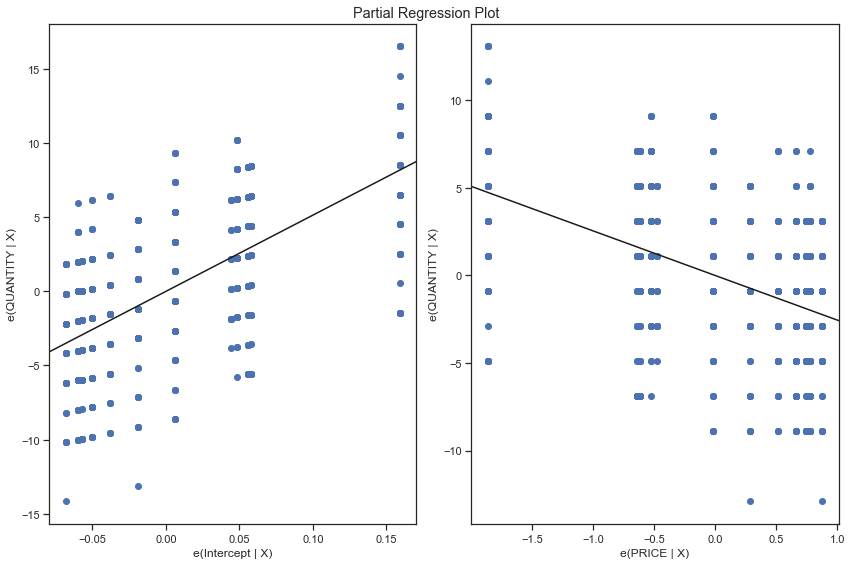

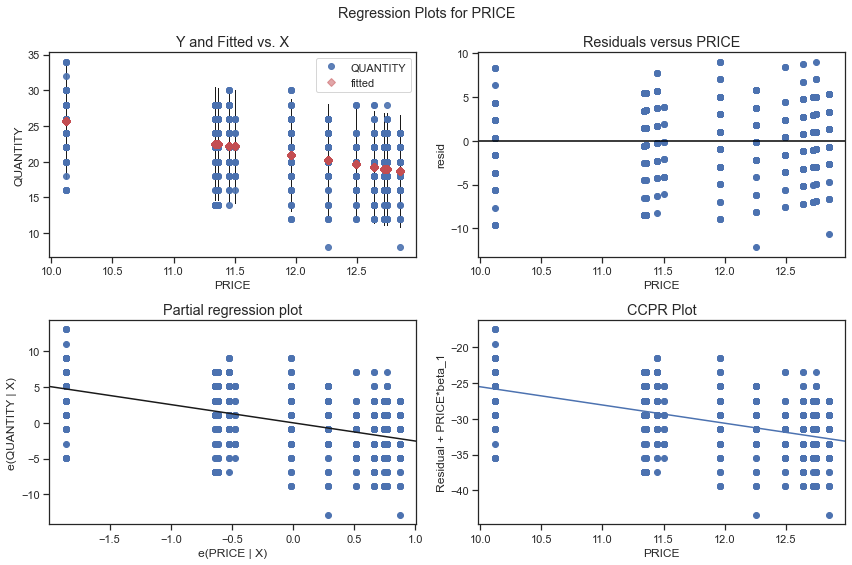

```python
model = ols("QUANTITY ~ PRICE", data=df).fit()
print(model.summary())
fig = plt.figure(figsize=(12,8))
fig = sm.graphics.plot_partregress_grid(model, fig=fig)
fig = plt.figure(figsize=(12,8))
fig = sm.graphics.plot_regress_exog(model, 'PRICE', fig=fig)
```

```python
elasticities = {}
```

```python
def create_model_and_find_elasticity(data):
    model = ols("QUANTITY ~ PRICE", data).fit()
    price_elasticity = model.params[1]
    print("Price elasticity of the product: " + str(price_elasticity))
    print(model.summary())
    fig = plt.figure(figsize=(12,8))
    fig = sm.graphics.plot_partregress_grid(model, fig=fig)
    return price_elasticity, model
```

```
Price elasticity of the product: -8.658581488470569
                            OLS Regression Results
==============================================================================
Dep. Variable:               QUANTITY   R-squared:                       0.813
Model:                            OLS   Adj. R-squared:                  0.813
Method:                 Least Squares   F-statistic:                     1804.
Date:                Mon, 07 Jun 2021   Prob (F-statistic):          5.51e-153
Time:                        21:38:33   Log-Likelihood:                -1038.8
No. Observations:                 416   AIC:                             2082.
Df Residuals:                     414   BIC:                             2090.
Df Model:                           1
Covariance Type:            nonrobust
==============================================================================
                 coef    std err          t      P>|t|      [0.025      0.975]
------------------------------------------------------------------------------
Intercept    220.3600      3.090     71.322      0.000     214.287     226.433
PRICE         -8.6586      0.204    -42.474      0.000      -9.059      -8.258
==============================================================================
Omnibus:                      281.738   Durbin-Watson:                   1.989
Prob(Omnibus):                  0.000   Jarque-Bera (JB):               25.687
Skew:                           0.012   Prob(JB):                     2.64e-06
Kurtosis:                       1.783   Cond. No.                         326.
==============================================================================

Notes:
[1] Standard Errors assume that the covariance matrix of the errors is correctly specified.
```

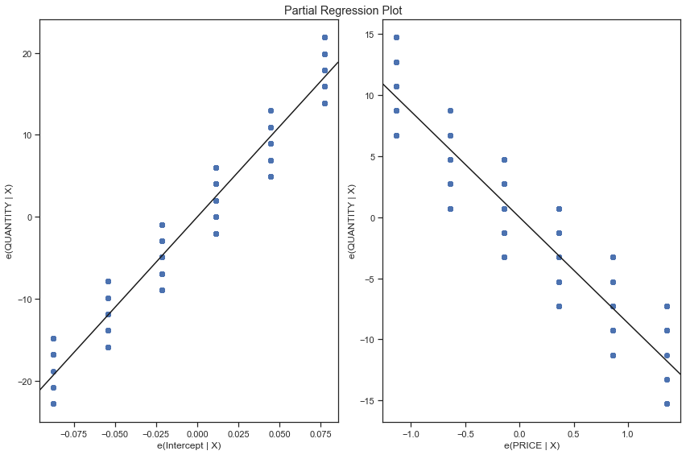

```python
price_elasticity, model_burger_1070 = create_model_and_find_elasticity(burger_1070)
elasticities['burger_1070'] = price_elasticity
```

```
Price elasticity of the product: -3.618990615456312
                            OLS Regression Results
==============================================================================
Dep. Variable:               QUANTITY   R-squared:                       0.467
Model:                            OLS   Adj. R-squared:                  0.466
Method:                 Least Squares   F-statistic:                     363.3
Date:                Mon, 07 Jun 2021   Prob (F-statistic):           1.34e-58
Time:                        21:38:34   Log-Likelihood:                -1021.5
No. Observations:                 416   AIC:                             2047.
Df Residuals:                     414   BIC:                             2055.
Df Model:                           1
Covariance Type:            nonrobust
==============================================================================
                 coef    std err          t      P>|t|      [0.025      0.975]
------------------------------------------------------------------------------
Intercept     76.1394      2.340     32.540      0.000      71.540      80.739
PRICE         -3.6190      0.190    -19.060      0.000      -3.992      -3.246
==============================================================================
Omnibus:                      248.712   Durbin-Watson:                   2.050
Prob(Omnibus):                  0.000   Jarque-Bera (JB):               25.007
Skew:                           0.033   Prob(JB):                     3.71e-06
Kurtosis:                       1.801   Cond. No.                         209.
==============================================================================

Notes:
[1] Standard Errors assume that the covariance matrix of the errors is correctly specified.
```

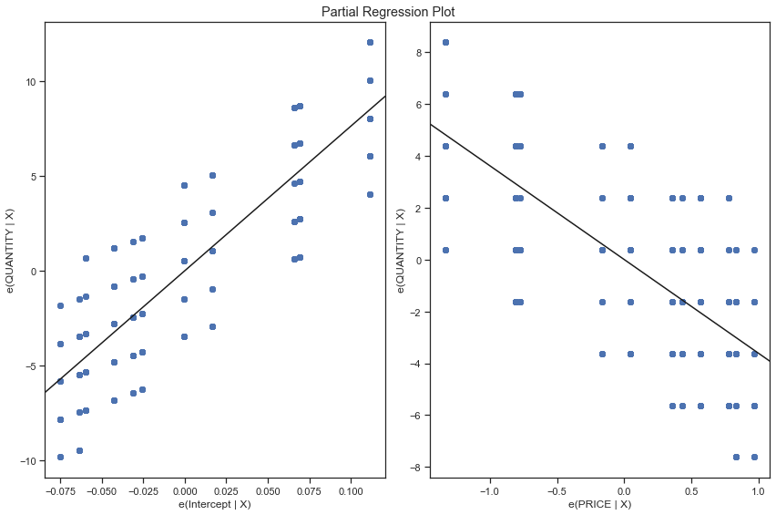

```python
burger2051_data = bau2_data[(bau2_data['ITEM_NAME'] == "BURGER") & (bau2_data['SELL_ID'] == 2051)]
elasticities['burger_2051'], model_burger_2051 = create_model_and_find_elasticity(burger2051_data)
```

```
Price elasticity of the product: -2.856702984559962
                            OLS Regression Results
==============================================================================
Dep. Variable:               QUANTITY   R-squared:                       0.433
Model:                            OLS   Adj. R-squared:                  0.432
Method:                 Least Squares   F-statistic:                     316.5
Date:                Mon, 07 Jun 2021   Prob (F-statistic):           5.32e-53
Time:                        21:38:34   Log-Likelihood:                -1014.7
No. Observations:                 416   AIC:                             2033.
Df Residuals:                     414   BIC:                             2041.
Df Model:                           1
Covariance Type:            nonrobust
==============================================================================
                 coef    std err          t      P>|t|      [0.025      0.975]
------------------------------------------------------------------------------
Intercept     56.2243      1.927     29.177      0.000      52.436      60.012
PRICE         -2.8567      0.161    -17.790      0.000      -3.172      -2.541
==============================================================================
Omnibus:                      139.808   Durbin-Watson:                   1.864
Prob(Omnibus):                  0.000   Jarque-Bera (JB):               21.201
Skew:                           0.025   Prob(JB):                     2.49e-05
Kurtosis:                       1.895   Cond. No.                         171.
==============================================================================

Notes:
[1] Standard Errors assume that the covariance matrix of the errors is correctly specified.
```

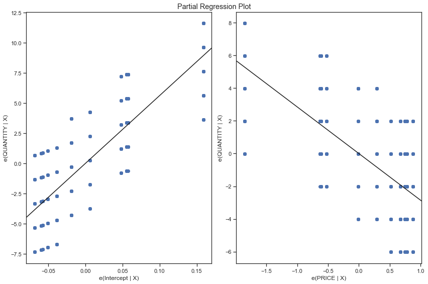

```python
burger2052_data = bau2_data[(bau2_data['ITEM_NAME'] == "BURGER") & (bau2_data['SELL_ID'] == 2052)]
elasticities['burger_2052'], model_burger_2052 = create_model_and_find_elasticity(burger2052_data)
```

```python
burger2053_data = bau2_data[(bau2_data['ITEM_NAME'] == "BURGER") & (bau2_data['SELL_ID'] == 2053)]
elasticities['burger_2053'], model_burger_2053 = create_model_and_find_elasticity(burger2053_data)
```

```
Price elasticity of the product: -6.164156666230159
                            OLS Regression Results
==============================================================================
Dep. Variable:               QUANTITY   R-squared:                       0.812
Model:                            OLS   Adj. R-squared:                  0.811
Method:                 Least Squares   F-statistic:                     1784.
Date:                Mon, 07 Jun 2021   Prob (F-statistic):          3.72e-152
Time:                        21:38:35   Log-Likelihood:                -1035.7
No. Observations:                 416   AIC:                             2075.
Df Residuals:                     414   BIC:                             2083.
Df Model:                           1
Covariance Type:            nonrobust
==============================================================================
                 coef    std err          t      P>|t|      [0.025      0.975]
------------------------------------------------------------------------------
Intercept    124.1417      1.742     71.270      0.000     120.718     127.566
PRICE         -6.1642      0.146    -42.234      0.000      -6.451      -5.877
==============================================================================
Omnibus:                      147.014   Durbin-Watson:                   2.072
Prob(Omnibus):                  0.000   Jarque-Bera (JB):               22.306
Skew:                          -0.110   Prob(JB):                     1.43e-05
Kurtosis:                       1.887   Cond. No.                         146.
==============================================================================

Notes:
[1] Standard Errors assume that the covariance matrix of the errors is correctly specified.
```

```
Price elasticity of the product: -7.4601034850849866
                            OLS Regression Results
==============================================================================
Dep. Variable:               QUANTITY   R-squared:                       0.360
Model:                            OLS   Adj. R-squared:                  0.359
Method:                 Least Squares   F-statistic:                     466.3
Date:                Mon, 07 Jun 2021   Prob (F-statistic):           2.00e-82
Time:                        21:38:35   Log-Likelihood:                -2994.5
No. Observations:                 832   AIC:                             5993.
Df Residuals:                     830   BIC:                             6002.
Df Model:                           1
Covariance Type:            nonrobust
==============================================================================
                 coef    std err          t      P>|t|      [0.025      0.975]
------------------------------------------------------------------------------
Intercept    131.4732      4.190     31.374      0.000     123.248     139.698
PRICE         -7.4601      0.345    -21.595      0.000      -8.138      -6.782
==============================================================================
Omnibus:                    24451.659   Durbin-Watson:                   3.618
Prob(Omnibus):                  0.000   Jarque-Bera (JB):               67.918
Skew:                          -0.113   Prob(JB):                     1.79e-15
Kurtosis:                       1.619   Cond. No.                         167.
==============================================================================

Notes:
[1] Standard Errors assume that the covariance matrix of the errors is correctly specified.
```

```
(-7.4601034850849866,
 <statsmodels.regression.linear_model.RegressionResultsWrapper at 0x7fec5f287e20>)
```

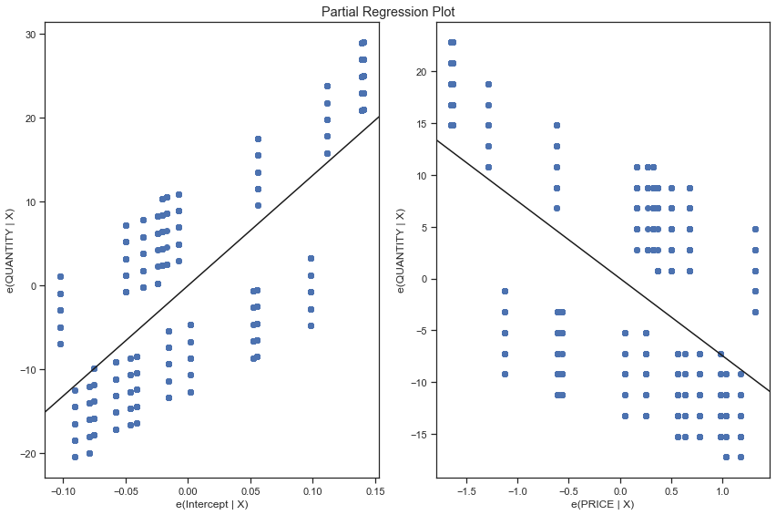

```python
coke_data = bau2_data[bau2_data['ITEM_NAME'] == "COKE"]
create_model_and_find_elasticity(coke_data)
```

2 coke are available in combo, while 1 is available as single.. So it is likely that the bottom distribution belongs to single purchases of coke. Let's verfy this

```python
# coke_data = bau2_data[(bau2_data['ITEM_NAME'] == "COKE") & (bau2_data['SELL_ID'] == 3067)]
# elasticities['coke_3067'], model_coke_3067 = create_model_and_find_elasticity(coke_data)
```

```python
try:
    coke_data = bau2_data[(bau2_data['ITEM_NAME'] == "COKE") & (bau2_data['SELL_ID'] == 3067)]
    elasticities['coke_3067'], model_coke_3067 = create_model_and_find_elasticity(coke_data)

except ValueError:  #raised if `y` is empty.
    pass
```

```python
coke_data
```

|  | SELL_ID | SELL_CATEGORY | ITEM_NAME | CALENDAR_DATE | PRICE | QUANTITY | YEAR | HOLIDAY | IS_WEEKEND | IS_SCHOOLBREAK | AVERAGE_TEMPERATURE | IS_OUTDOOR |
| --- | --- | --- | --- | --- | --- | --- | --- | --- | --- | --- | --- | --- |

```python
coke_data_2053 = bau2_data[(bau2_data['ITEM_NAME'] == "COKE") & (bau2_data['SELL_ID'] == 2053)]
elasticities['coke_2053'], model_coke_2053 = create_model_and_find_elasticity(coke_data_2053)
```

```
Price elasticity of the product: -6.164156666230159
                            OLS Regression Results
==============================================================================
Dep. Variable:               QUANTITY   R-squared:                       0.812
Model:                            OLS   Adj. R-squared:                  0.811
Method:                 Least Squares   F-statistic:                     1784.
Date:                Mon, 07 Jun 2021   Prob (F-statistic):          3.72e-152
Time:                        21:38:36   Log-Likelihood:                -1035.7
No. Observations:                 416   AIC:                             2075.
Df Residuals:                     414   BIC:                             2083.
Df Model:                           1
Covariance Type:            nonrobust
==============================================================================
                 coef    std err          t      P>|t|      [0.025      0.975]
------------------------------------------------------------------------------
Intercept    124.1417      1.742     71.270      0.000     120.718     127.566
PRICE         -6.1642      0.146    -42.234      0.000      -6.451      -5.877
==============================================================================
Omnibus:                      147.014   Durbin-Watson:                   2.072
Prob(Omnibus):                  0.000   Jarque-Bera (JB):               22.306
Skew:                          -0.110   Prob(JB):                     1.43e-05
Kurtosis:                       1.887   Cond. No.                         146.
==============================================================================

Notes:
[1] Standard Errors assume that the covariance matrix of the errors is correctly specified.
```

```
Price elasticity of the product: -3.618990615456312
                            OLS Regression Results
==============================================================================
Dep. Variable:               QUANTITY   R-squared:                       0.467
Model:                            OLS   Adj. R-squared:                  0.466
Method:                 Least Squares   F-statistic:                     363.3
Date:                Mon, 07 Jun 2021   Prob (F-statistic):           1.34e-58
Time:                        21:38:36   Log-Likelihood:                -1021.5
No. Observations:                 416   AIC:                             2047.
Df Residuals:                     414   BIC:                             2055.
Df Model:                           1
Covariance Type:            nonrobust
==============================================================================
                 coef    std err          t      P>|t|      [0.025      0.975]
------------------------------------------------------------------------------
Intercept     76.1394      2.340     32.540      0.000      71.540      80.739
PRICE         -3.6190      0.190    -19.060      0.000      -3.992      -3.246
==============================================================================
Omnibus:                      248.712   Durbin-Watson:                   2.050
Prob(Omnibus):                  0.000   Jarque-Bera (JB):               25.007
Skew:                           0.033   Prob(JB):                     3.71e-06
Kurtosis:                       1.801   Cond. No.                         209.
==============================================================================

Notes:
[1] Standard Errors assume that the covariance matrix of the errors is correctly specified.
```

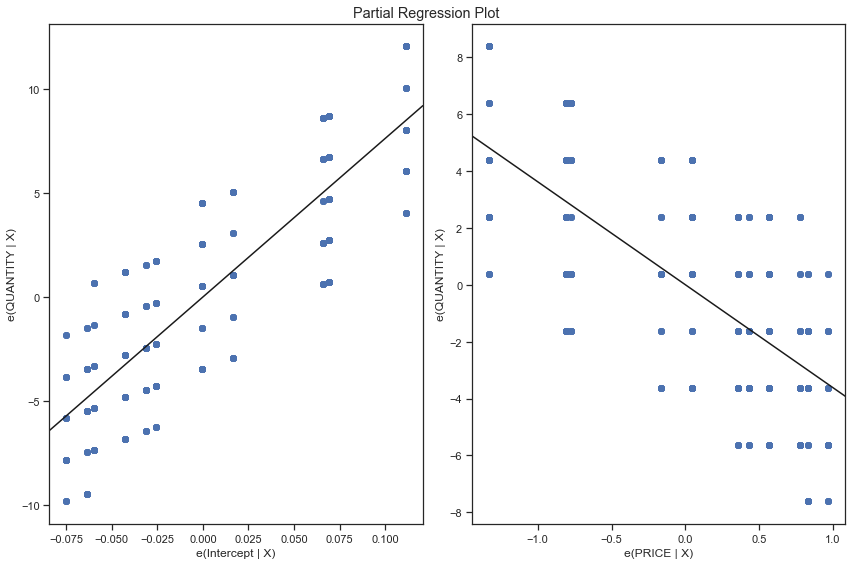

```python
coke_data_2051 = bau2_data[(bau2_data['ITEM_NAME'] == "COKE") & (bau2_data['SELL_ID'] == 2051)]
elasticities['coke_2051'], model_coke_2051 = create_model_and_find_elasticity(coke_data_2051)
```

```
Price elasticity of the product: -2.856702984559962
                            OLS Regression Results
==============================================================================
Dep. Variable:               QUANTITY   R-squared:                       0.433
Model:                            OLS   Adj. R-squared:                  0.432
Method:                 Least Squares   F-statistic:                     316.5
Date:                Mon, 07 Jun 2021   Prob (F-statistic):           5.32e-53
Time:                        21:38:37   Log-Likelihood:                -1014.7
No. Observations:                 416   AIC:                             2033.
Df Residuals:                     414   BIC:                             2041.
Df Model:                           1
Covariance Type:            nonrobust
==============================================================================
                 coef    std err          t      P>|t|      [0.025      0.975]
------------------------------------------------------------------------------
Intercept     56.2243      1.927     29.177      0.000      52.436      60.012
PRICE         -2.8567      0.161    -17.790      0.000      -3.172      -2.541
==============================================================================
Omnibus:                      139.808   Durbin-Watson:                   1.864
Prob(Omnibus):                  0.000   Jarque-Bera (JB):               21.201
Skew:                           0.025   Prob(JB):                     2.49e-05
Kurtosis:                       1.895   Cond. No.                         171.
==============================================================================

Notes:
[1] Standard Errors assume that the covariance matrix of the errors is correctly specified.
```

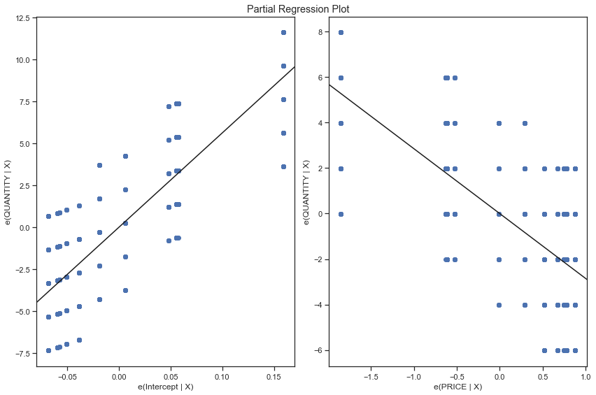

```python
lemonade_data_2052 = bau2_data[(bau2_data['ITEM_NAME'] == "LEMONADE") & (bau2_data['SELL_ID'] == 2052)]
elasticities['lemonade_2052'], model_lemonade_2052 = create_model_and_find_elasticity(lemonade_data_2052)
```

```python
try:
    lemonade_data_3028 = bau2_data[(bau2_data['ITEM_NAME'] == "LEMONADE") & (bau2_data['SELL_ID'] == 3028)]
    elasticities['lemonade_3028'], model_lemonade_3028 = create_model_and_find_elasticity(lemonade_data_3028)
except ValueError:
    pass
```

```python
try:
    coffee_data_2053 = bau2_data[(bau2_data['ITEM_NAME'] == "COFFEE") & (bau2_data['SELL_ID'] == 2053)]
    elasticities['coffee_2053'], model_coffee_2053 = create_model_and_find_elasticity(coffee_data_2053)
except ValueError:
    pass
```

```
Price elasticity of the product: -6.164156666230159
                            OLS Regression Results
==============================================================================
Dep. Variable:               QUANTITY   R-squared:                       0.812
Model:                            OLS   Adj. R-squared:                  0.811
Method:                 Least Squares   F-statistic:                     1784.
Date:                Mon, 07 Jun 2021   Prob (F-statistic):          3.72e-152
Time:                        21:38:37   Log-Likelihood:                -1035.7
No. Observations:                 416   AIC:                             2075.
Df Residuals:                     414   BIC:                             2083.
Df Model:                           1
Covariance Type:            nonrobust
==============================================================================
                 coef    std err          t      P>|t|      [0.025      0.975]
------------------------------------------------------------------------------
Intercept    124.1417      1.742     71.270      0.000     120.718     127.566
PRICE         -6.1642      0.146    -42.234      0.000      -6.451      -5.877
==============================================================================
Omnibus:                      147.014   Durbin-Watson:                   2.072
Prob(Omnibus):                  0.000   Jarque-Bera (JB):               22.306
Skew:                          -0.110   Prob(JB):                     1.43e-05
Kurtosis:                       1.887   Cond. No.                         146.
==============================================================================

Notes:
[1] Standard Errors assume that the covariance matrix of the errors is correctly specified.
```

```python
try:
    coffee_data_3055 = bau2_data[(bau2_data['ITEM_NAME'] == "COFFEE") & (bau2_data['SELL_ID'] == 3055)]
    elasticities['coffee_3055'], model_coffee_3055 = create_model_and_find_elasticity(coffee_data_3055)
except ValueError:
    pass
```

## List in a table the items and their price elasticities

```python
elasticities
```

```
{'burger_1070': -8.658581488470569,
 'burger_2051': -3.618990615456312,
 'burger_2052': -2.856702984559962,
 'burger_2053': -6.164156666230159,
 'coke_2053': -6.164156666230159,
 'coke_2051': -3.618990615456312,
 'lemonade_2052': -2.856702984559962,
 'coffee_2053': -6.164156666230159}
```

# Find optimal price for maximum profit

Now, let's take coke (the sell_id was 2051 for the last coke data) and since we do not the buying price of coke, let''s assume it to be a little less than the minimum coke price in the dataset

```python
coke_data = coke_data_2053
```

```python
coke_data.PRICE.min()
```

```
10.45
```

```python
coke_data.PRICE.max()
```

```
13.41
```

Let's take 9 as the buying price of coke. We now want to be able to set the price of coke to get the maximum profit. PRICE is the selling price

```python
buying_price_coke = 9
```

$$coke data.PROFIT = (coke data.PRICE - buying price coke) * coke data.QUANTITY$$

Let's see the profit for various price points:

```python
start_price = 9.5
end_price = 20
```

```python
test = pd.DataFrame(columns = ["PRICE", "QUANTITY"])
```

```python
test['PRICE'] = np.arange(start_price, end_price,0.01)
```

```python
test['QUANTITY'] = model_coke_2051.predict(test['PRICE'])
```

```python
test
```

|  | PRICE | QUANTITY |
| --- | --- | --- |
| 0 | 9.50 | 41.759021 |
| 1 | 9.51 | 41.722831 |
| 2 | 9.52 | 41.686641 |
| 3 | 9.53 | 41.650451 |
| 4 | 9.54 | 41.614261 |
| 5 | 9.55 | 41.578071 |
| 6 | 9.56 | 41.541881 |
| 7 | 9.57 | 41.505691 |
| 8 | 9.58 | 41.469501 |
| 9 | 9.59 | 41.433312 |
| 10 | 9.60 | 41.397122 |
| 11 | 9.61 | 41.360932 |
| 12 | 9.62 | 41.324742 |
| 13 | 9.63 | 41.288552 |
| 14 | 9.64 | 41.252362 |
| 15 | 9.65 | 41.216172 |
| 16 | 9.66 | 41.179982 |
| 17 | 9.67 | 41.143792 |
| 18 | 9.68 | 41.107602 |
| 19 | 9.69 | 41.071412 |
| 20 | 9.70 | 41.035223 |
| 21 | 9.71 | 40.999033 |
| 22 | 9.72 | 40.962843 |
| 23 | 9.73 | 40.926653 |
| 24 | 9.74 | 40.890463 |
| 25 | 9.75 | 40.854273 |
| 26 | 9.76 | 40.818083 |
| 27 | 9.77 | 40.781893 |
| 28 | 9.78 | 40.745703 |
| 29 | 9.79 | 40.709513 |

[output cut: 1020 more lines]

```python
test['PROFIT'] = (test["PRICE"] - buying_price_coke) * test["QUANTITY"]
```

```python
test
```

|  | PRICE | QUANTITY | PROFIT |
| --- | --- | --- | --- |
| 0 | 9.50 | 41.759021 | 20.879510 |
| 1 | 9.51 | 41.722831 | 21.278644 |
| 2 | 9.52 | 41.686641 | 21.677053 |
| 3 | 9.53 | 41.650451 | 22.074739 |
| 4 | 9.54 | 41.614261 | 22.471701 |
| 5 | 9.55 | 41.578071 | 22.867939 |
| 6 | 9.56 | 41.541881 | 23.263454 |
| 7 | 9.57 | 41.505691 | 23.658244 |
| 8 | 9.58 | 41.469501 | 24.052311 |
| 9 | 9.59 | 41.433312 | 24.445654 |
| 10 | 9.60 | 41.397122 | 24.838273 |
| 11 | 9.61 | 41.360932 | 25.230168 |
| 12 | 9.62 | 41.324742 | 25.621340 |
| 13 | 9.63 | 41.288552 | 26.011788 |
| 14 | 9.64 | 41.252362 | 26.401512 |
| 15 | 9.65 | 41.216172 | 26.790512 |
| 16 | 9.66 | 41.179982 | 27.178788 |
| 17 | 9.67 | 41.143792 | 27.566341 |
| 18 | 9.68 | 41.107602 | 27.953170 |
| 19 | 9.69 | 41.071412 | 28.339275 |
| 20 | 9.70 | 41.035223 | 28.724656 |
| 21 | 9.71 | 40.999033 | 29.109313 |
| 22 | 9.72 | 40.962843 | 29.493247 |
| 23 | 9.73 | 40.926653 | 29.876457 |
| 24 | 9.74 | 40.890463 | 30.258943 |
| 25 | 9.75 | 40.854273 | 30.640705 |
| 26 | 9.76 | 40.818083 | 31.021743 |
| 27 | 9.77 | 40.781893 | 31.402058 |
| 28 | 9.78 | 40.745703 | 31.781649 |
| 29 | 9.79 | 40.709513 | 32.160516 |

[output cut: 1020 more lines]

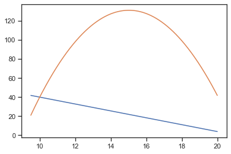

```python
plt.plot(test['PRICE'],test['QUANTITY'])
plt.plot(test['PRICE'],test['PROFIT'])
plt.show()
```

Let's find the exact price at which maximum profit is gained:

```python
ind = np.where(test['PROFIT'] == test['PROFIT'].max())[0][0]
```

```python
test.loc[[ind]]
```

|  | PRICE | QUANTITY | PROFIT |
| --- | --- | --- | --- |
| 552 | 15.02 | 21.782193 | 131.128799 |

```python
def find_optimal_price(data, model, buying_price):
    start_price = data.PRICE.min() - 1
    end_price = data.PRICE.min() + 10
    test = pd.DataFrame(columns = ["PRICE", "QUANTITY"])
    test['PRICE'] = np.arange(start_price, end_price,0.01)
    test['QUANTITY'] = model.predict(test['PRICE'])
    test['PROFIT'] = (test["PRICE"] - buying_price) * test["QUANTITY"]
    plt.plot(test['PRICE'],test['QUANTITY'])
    plt.plot(test['PRICE'],test['PROFIT'])
    plt.show()
    ind = np.where(test['PROFIT'] == test['PROFIT'].max())[0][0]
    values_at_max_profit = test.iloc[[ind]]
    return values_at_max_profit
```

## Calculate the optimal price for all and list in table

```python
optimal_price = {}
buying_price = 9
```

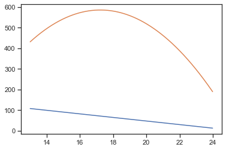

```python
optimal_price['burger_1070'] = find_optimal_price(burger_1070, model_burger_1070, buying_price)
```

```python
optimal_price
```

```
{'burger_1070':      PRICE   QUANTITY      PROFIT
 422  17.22  71.259194  585.750572}
```

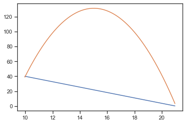

```python
optimal_price['burger_2051'] = find_optimal_price(burger2051_data, model_burger_2051, buying_price)
```

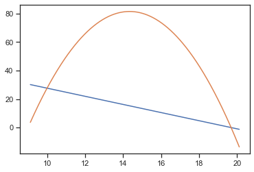

```python
optimal_price['burger_2052'] = find_optimal_price(burger2052_data, model_burger_2052, buying_price)
```

```python
optimal_price['burger_2053'] = find_optimal_price(burger2053_data, model_burger_2053, buying_price)
```

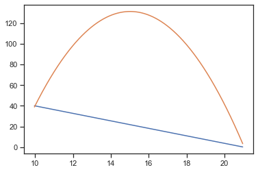

```python
optimal_price['coke_2051'] = find_optimal_price(coke_data_2051, model_coke_2051, buying_price)
```

```python
optimal_price['coke_2053'] = find_optimal_price(coke_data_2053, model_coke_2053, buying_price)
```

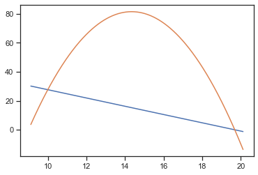

```python
optimal_price['lemonade_2052'] = find_optimal_price(lemonade_data_2052, model_lemonade_2052, buying_price)
```

```python
optimal_price['coffee_2053'] = find_optimal_price(coffee_data_2053, model_coffee_2053, buying_price)
```

```python
optimal_price
```

```
{'burger_1070':      PRICE   QUANTITY      PROFIT
 422  17.22  71.259194  585.750572,
 'burger_2051':      PRICE   QUANTITY      PROFIT
 505  15.02  21.782193  131.128799,
 'burger_2052':      PRICE   QUANTITY     PROFIT
 522  14.34  15.259215  81.484211,
 'burger_2053':      PRICE   QUANTITY      PROFIT
 512  14.57  34.329951  191.217825,
 'coke_2051':      PRICE   QUANTITY      PROFIT
 505  15.02  21.782193  131.128799,
 'coke_2053':      PRICE   QUANTITY      PROFIT
 512  14.57  34.329951  191.217825,
 'lemonade_2052':      PRICE   QUANTITY     PROFIT
 522  14.34  15.259215  81.484211,
 'coffee_2053':      PRICE   QUANTITY      PROFIT
 512  14.57  34.329951  191.217825}
```

```python
coke_data_2051.PRICE.describe()
```

```
count    416.000000
mean      12.301562
std        0.730620
min       10.970000
25%       11.530000
50%       12.350000
75%       12.870000
max       13.270000
Name: PRICE, dtype: float64
```

# Conclusion

This is the price the cafe should set on it's item to earn maximum profit based on it's previous sales data. It is important to note that this is on a normal day. On 'other' days such as a holiday, or an event taking place have a different impact on customer buying behaviours and pattern. Usually an increase in consumption is seen on such days. These must be treated separately. Similarly, it is important to remove any external effects other than price that will affect the purchase behaviours of customers including the datapoints when the item was on discount.

Once, the new prices are put up, it is important to continuously monitor the sales and profit. If this method of pricing is a part of a rpoduct, a dashboard can be created for the purpose of monitoring these items and calculating the lift in the profit.